# Spending Tracking

- Budget Planning
  - Monthly Spend
    - Average Days Between Internet Payments
    - Monthly Spend - Ignores Cash
    - Monthly Spend Full
    - Inference for Monthly Spend Distrubution
    - Inference for Time between Internet Payments Distrubution
    - Distrubution of Monthly Spend Means
    - Distrubution of Time between Internet Payments Distrubution Means
    - Running Monte Carlo
    - Internet Paydates Likely
  - Scenarios
    - Spending Scenario/Guide
    - Buying Pizza
    - Rebalancing the Spending Plan
    - A More Complicated, Example - Planning for the Future
    - Other Stats
    - (Surplus, Surplus over Budget)

# Budget Planning

## Monthly Spend

### Average Days Between Internet Payments

```
val netinf ∈ float [] = [|40.0; 35.0; 31.0|]
```

```
val calcMonthly ∈
  project:('a ⟹ float) ⟹ months:((int ⨯ int) ⨯ 'a []) [] ⟹ SpendInfo
```

### Monthly Spend - Ignores Cash

```fsharp
calcMonthly fst3 monthsb
```

```
val it ∈ SpendInfo =
  {MonthlySpend =
    [|((2, 2016), -30000.0); ((1, 2016), 466.99); ((12, 2015), -14505.24);
      ((11, 2015), -14786.25); ((10, 2015), -24954.45)|];
   TotalSpend = -58824.5;
   Target = 69632.37498;
   Surplus = 10807.87498;}
```

### Monthly Spend Full

```fsharp
let actualSpend = calcMonthly fst monthly
```

```
val actualSpend ∈ SpendInfo =
  {MonthlySpend =
    [|((11, 2015), -18786.25); ((12, 2015), -29005.24); ((1, 2016), -6533.01);
      ((2, 2016), -17000.0); ((10, 2015), -24954.45)|];
   TotalSpend = -71324.5;
   Target = 69632.37983;
   Surplus = -1692.12017;}
```

```fsharp
let mdat = actualSpend.MonthlySpend |> Array.map (snd)
let mvar, mmean = varianceAndMean mdat
sqrt mvar
```

```
val mdat ∈ float [] = [|-18786.25; -29005.24; -6533.01; -17000.0; -24954.45|]
val mvar ∈ float = 58940937.67
val mmean ∈ float = -19255.79
val it ∈ float = 7677.300155
```

Click to Expand Inference code

```
val runInference ∈
  meanunc:float ⟹
    mvar:float ⨯ mmean:float ⟹ mdat:float [] ⟹ Gaussian ⨯ Gamma ⨯ float
```

### Inference for Monthly Spend Distrubution

```fsharp
let posterior, prc, stdv = runInference 10000.0 (mvar,mmean) mdat
posterior.GetVariance() |> sqrt, posterior.GetMean()
```

```
val stdv ∈ float = 7677.950846
val prc ∈ Gamma = Gamma(2.5, 6.785e-09)[mean=1.696e-08]
val posterior ∈ Gaussian = Gaussian(-1.926e+04, 9992)
val it ∈ float ⨯ float = (99.95761881, -19255.79)
```

### Inference for Time between Internet Payments Distrubution

```fsharp
let varinet, minet = varianceAndMean netinf
let inetposterior, inetprc, istdv = runInference 5. (100., 50.) netinf
```

```
val varinet ∈ float = 13.55555556
val minet ∈ float = 35.33333333
val istdv ∈ float = 14.28972811
val inetprc ∈ Gamma = Gamma(1.51, 0.003243)[mean=0.004897]
val inetposterior ∈ Gaussian = Gaussian(49, 4.658)
```

### Distrubution of Monthly Spend Means

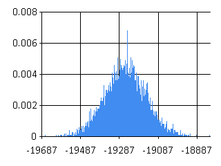

```fsharp
hist (round 0) id [|for _ in 0..9999 -> posterior.Sample() |]
|> Chart.Column
```

### Distrubution of Time between Internet Payments Distrubution Means

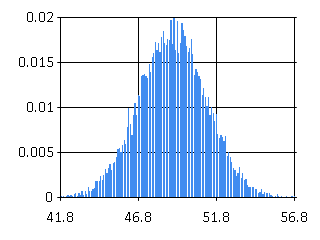

```fsharp
hist (round 1) id [|for _ in 0..9999 -> inetposterior.Sample() |]
|> Chart.Column
```

```fsharp
let totbudget = 134669. + 60000. + actualSpend.TotalSpend
let startbudget = 134669. + 60000.
```

```
val totbudget ∈ float = 123344.5
val startbudget ∈ float = 194669.0
```

```fsharp
totbudget / -mmean, startbudget / -mmean
```

```
val it ∈ float ⨯ float = (6.405579828, 10.10963456)
```

Click to Expand SAMPLING

```
val sampleNormal ∈ prc∈Gamma ⟹ posterior∈Gaussian ⟹ float
val simhist ∈
  prc:Gamma ⟹
    posterior:Gaussian ⟹ spent:float list ⟹ left:float ⟹ float list
```

```fsharp
let tbudget = totbudget - rmspend
```

```
val tbudget ∈ float = 140344.5
```

### Running Monte Carlo

Works by sampling the distrubition over means and then sampling for a value from said distrubution. Run many times with statistic of all gathered.

Click to Expand SCENARIOS, MONTE CARLO

### Internet Paydates Likely

```fsharp
let  npers, iavg = run_monteCarlob 6 |> (keepRight Array.colAverageFloats)

npers
|> Array.fold (fun (d:DateTime,l) dur -> let nd = d.AddDays dur in nd, nd::l) (DateTime(2016,2,5),[])
```

```
val npers ∈ float [] =
  [|48.73131554; 49.19973015; 48.76436472; 48.86016683; 49.29649589;
    48.87808256|]
val iavg ∈ float = 48.95502595
val it ∈ DateTime ⨯ DateTime list =
  (11/24/2016 5:31:25 PM,
   [11/24/2016 5:31:25 PM; 10/6/2016 8:26:59 PM; 8/18/2016 1:20:01 PM;
    6/30/2016 4:41:23 PM; 5/12/2016 10:20:42 PM; 3/24/2016 5:33:05 PM])
```